# 7. Survival analysis

## Purpose

This script fits Cox proportional hazards models for the four ELISA-validated biomarkers across all outcomes. It produces the main models results (Table 2), the outcome-specific tables (Tables S12 to S14), the main Kaplan-Meier figure (Fig. 5) and the outcome-specific KM figures (Figs. S7 to S9). It also produces the non-linearity spline models (Fig. S6), the proportional hazards diagnostics (Fig. S11, Table S16), and the quartile forest plot (Fig. S5).

## Reproducibility

This script runs entirely from the public repository. Only `elisa_validation.tsv` and `metadata.tsv` are needed.

```r
library(broom)
library(ggpubr)
library(ggsurvfit)
library(gtsummary)
library(patchwork)
library(survival)
library(tidyverse)
```

## Load public data

`time` (time-to-SNAE-or-censoring) is precomputed and included in `metadata.tsv` directly, so this script is fully reproducible from the public repository. See `01_matching.qmd` / `02_1_preprocess_metadata.qmd` for how the underlying dates were used to derive it (not runnable publicly, documented there for transparency).

```r
metadata <- read_tsv("../data/metadata.tsv", show_col_types = FALSE) |>
    mutate(CD4_0_200 = factor(ifelse(CD4_0 < 200, 1, 0)))
```

# Models

The four ELISA-validated biomarkers (LGALS9, CCL13, DAPP1, SKAP2) go through identical data prep and Cox modelling.

## Helper functions

```r
markers <- c("LGALS9", "CCL13", "DAPP1", "SKAP2")
outcomes <- c("group", "nadm", "mace", "death_all")

# Builds one marker's analysis dataset: ELISA concentration + metadata +
# time-to-event, quartile-coded.
build_marker_data <- function(marker) {
    read_tsv("../data/elisa_validation.tsv") |>
        filter(assay == marker) |>
        left_join(
            metadata |> dplyr::select(sid, group, nadm, mace, death_all, CD4_0, CD4_0_200, time),
            by = "sid"
        ) |>
        mutate(quantile = factor(ntile(mean_conc, 4))) |>
        filter(time > 0) |>
        mutate(group = if_else(group == "Event", 1, 0))
}

# Categorical quartile Cox model (Q2/Q3/Q4 vs Q1), for one outcome, crude
# or CD4<200-adjusted.
fit_categorical_model <- function(data, event_var, adjusted = FALSE) {
    model_data <- data |>
        mutate(
            time, event = as.numeric(as.character(.data[[event_var]])),
            quantile, CD4_0_200,
            .keep = "none"
        ) |>
        filter(!is.na(time), time > 0, !is.na(event), !adjusted | !is.na(CD4_0_200))

    rhs <- if (adjusted) "quantile + CD4_0_200" else "quantile"
    coxph(as.formula(paste0("Surv(time, event) ~ ", rhs)), data = model_data)
}

# Linear-trend Cox model (one HR per one-quartile increase), for one
# outcome, crude or CD4<200-adjusted. Used for Global P values throughout
# (Table 2/S12-S14 and the KM figure annotations).
fit_trend_model <- function(data, event_var, adjusted = FALSE) {
    model_data <- data |>
        mutate(
            time, event = as.numeric(as.character(.data[[event_var]])),
            q = as.numeric(quantile), CD4_0_200,
            .keep = "none"
        ) |>
        filter(!is.na(time), time > 0, !is.na(event), !adjusted | !is.na(CD4_0_200))

    rhs <- if (adjusted) "q + CD4_0_200" else "q"
    coxph(as.formula(paste0("Surv(time, event) ~ ", rhs)), data = model_data)
}

# Event counts per quantile, for each outcome (used to populate Tables).
count_events_by_quantile <- function(data) {
    purrr::map(outcomes, function(outcome) {
        data |> group_by(quantile) |> dplyr::count(.data[[outcome]]) |> filter(.data[[outcome]] == 1)
    }) |> setNames(outcomes)
}
```

## Fit models

```r
marker_data <- purrr::map(markers, build_marker_data) |> setNames(markers)
```

Categorical (Q2/Q3/Q4 vs Q1) models, crude and CD4<200-adjusted, for every marker and outcome:

```r
categorical_models <- purrr::map(marker_data, function(data) {
    purrr::map(outcomes, function(outcome) {
        list(
            crude = fit_categorical_model(data, outcome, adjusted = FALSE),
            adjusted = fit_categorical_model(data, outcome, adjusted = TRUE)
        )
    }) |> setNames(outcomes)
})
```

Linear-trend models, crude and CD4<200-adjusted, for the Global P values:

```r
trend_models <- purrr::map(marker_data, function(data) {
    purrr::map(outcomes, function(outcome) {
        list(
            crude = fit_trend_model(data, outcome, adjusted = FALSE),
            adjusted = fit_trend_model(data, outcome, adjusted = TRUE)
        )
    }) |> setNames(outcomes)
})
```

Event counts per marker/outcome/quartile:

```r
marker_event_counts <- purrr::map(marker_data, count_events_by_quantile)
```

# Tables

## Marker-level summary tables (unadjusted + adjusted, main SNAE comparison)

```r
print_marker_tables <- function(models, marker) {
    print_one <- function(model) {
        tidy(model, conf.int = TRUE, exponentiate = TRUE) |> print()
        model |>
            tbl_regression(exponentiate = TRUE, label = list(quantile ~ paste(marker, "Quantile"))) |>
            bold_p(t = 0.05) |>
            bold_labels() |>
            print()
    }
    print_one(models$group$crude)
    print_one(models$group$adjusted)
}

purrr::iwalk(categorical_models, ~ print_marker_tables(.x, .y))
```

[output not shown]

[output cut: 3941 more lines]

[output not shown]

## Crude and adjusted hazard ratios by outcome (Table 2 / Tables S12-S14)

One table per outcome, matching the manuscript’s published layout: a Ref. row for Q1, per-quartile crude/adjusted HR (95% CI), number of events per quartile, and a Global P value row (from the linear-trend models).

```r
format_hr <- function(estimate, low, high) {
    ifelse(is.na(estimate), NA_character_,
           ifelse(is.na(low), "Ref.", sprintf("%.2f (%.2f-%.2f)", estimate, low, high)))
}

build_outcome_table <- function(outcome) {
    quartile_rows <- purrr::map_dfr(markers, function(marker) {
        crude <- tidy(categorical_models[[marker]][[outcome]]$crude, exponentiate = TRUE, conf.int = TRUE) |>
            filter(str_detect(term, "^quantile")) |>
            mutate(quartile = str_remove(term, "quantile"), crude_estimate = estimate,
                   crude_low = conf.low, crude_high = conf.high, .keep = "none")
        adj <- tidy(categorical_models[[marker]][[outcome]]$adjusted, exponentiate = TRUE, conf.int = TRUE) |>
            filter(str_detect(term, "^quantile")) |>
            mutate(quartile = str_remove(term, "quantile"), adj_estimate = estimate,
                   adj_low = conf.low, adj_high = conf.high, .keep = "none")
        ref <- tibble(quartile = "1", crude_estimate = 1, crude_low = NA, crude_high = NA,
                      adj_estimate = 1, adj_low = NA, adj_high = NA)
        n_events <- marker_event_counts[[marker]][[outcome]] |>
            mutate(quartile = as.character(quantile), n_events = n, .keep = "none")

        bind_rows(ref, crude |> left_join(adj, by = "quartile")) |>
            left_join(n_events, by = "quartile") |>
            mutate(
                biomarker = marker, quartile, n_events,
                HR = format_hr(crude_estimate, crude_low, crude_high),
                Adjusted_HR = format_hr(adj_estimate, adj_low, adj_high),
                .keep = "none"
            )
    })

    global_p <- purrr::map_dfr(markers, function(marker) {
        tibble(
            biomarker = marker, quartile = "Global P value", n_events = NA_integer_,
            HR = formatC(tidy(trend_models[[marker]][[outcome]]$crude)$p.value[1], digits = 3, format = "f"),
            Adjusted_HR = formatC(tidy(trend_models[[marker]][[outcome]]$adjusted)$p.value[1], digits = 3, format = "f")
        )
    })

    bind_rows(quartile_rows, global_p) |>
        mutate(quartile = factor(quartile, levels = c("1", "2", "3", "4", "Global P value"))) |>
        pivot_wider(
            id_cols = quartile,
            names_from = biomarker,
            values_from = c(n_events, HR, Adjusted_HR),
            names_glue = "{biomarker}_{.value}"
        ) |>
        arrange(quartile) |>
        dplyr::select(quartile, starts_with("CCL13"), starts_with("DAPP1"),
                      starts_with("LGALS9"), starts_with("SKAP2"))
}
```

```r
table2 <- build_outcome_table("group")
table2
```

| quartile | CCL13_n_events | CCL13_HR | CCL13_Adjusted_HR | DAPP1_n_events | DAPP1_HR | DAPP1_Adjusted_HR | LGALS9_n_events | LGALS9_HR | LGALS9_Adjusted_HR | SKAP2_n_events | SKAP2_HR | SKAP2_Adjusted_HR |
| --- | --- | --- | --- | --- | --- | --- | --- | --- | --- | --- | --- | --- |
| 1 | 12 | Ref. | Ref. | 14 | Ref. | Ref. | 12 | Ref. | Ref. | 17 | Ref. | Ref. |
| 2 | 17 | 1.45 (0.69-3.05) | 1.36 (0.61-3.00) | 17 | 1.08 (0.53-2.18) | 1.19 (0.55-2.54) | 18 | 2.14 (1.03-4.46) | 2.27 (1.04-4.95) | 17 | 1.16 (0.59-2.27) | 1.21 (0.59-2.49) |
| 3 | 22 | 2.35 (1.16-4.75) | 2.39 (1.15-4.97) | 22 | 2.99 (1.50-5.97) | 3.27 (1.57-6.80) | 17 | 2.04 (0.97-4.30) | 2.10 (0.97-4.56) | 16 | 1.12 (0.57-2.22) | 1.28 (0.62-2.62) |
| 4 | 16 | 1.30 (0.62-2.76) | 1.34 (0.62-2.89) | 14 | 1.05 (0.50-2.20) | 1.17 (0.54-2.56) | 20 | 2.37 (1.15-4.88) | 2.46 (1.12-5.42) | 16 | 1.09 (0.55-2.16) | 1.18 (0.58-2.39) |
| Global P value | NA | 0.306 | 0.271 | NA | 0.356 | 0.277 | NA | 0.028 | 0.038 | NA | 0.830 | 0.631 |

```r
# table2 |> write_tsv("../results/table2.tsv")
```

```r
tableS12 <- build_outcome_table("nadm")
tableS12
```

| quartile | CCL13_n_events | CCL13_HR | CCL13_Adjusted_HR | DAPP1_n_events | DAPP1_HR | DAPP1_Adjusted_HR | LGALS9_n_events | LGALS9_HR | LGALS9_Adjusted_HR | SKAP2_n_events | SKAP2_HR | SKAP2_Adjusted_HR |
| --- | --- | --- | --- | --- | --- | --- | --- | --- | --- | --- | --- | --- |
| 1 | 9 | Ref. | Ref. | 12 | Ref. | Ref. | 12 | Ref. | Ref. | 11 | Ref. | Ref. |
| 2 | 11 | 1.23 (0.51-2.99) | 1.28 (0.50-3.28) | 12 | 0.88 (0.40-1.97) | 0.88 (0.37-2.07) | 11 | 1.31 (0.57-2.98) | 1.45 (0.61-3.47) | 12 | 1.31 (0.58-2.99) | 1.12 (0.47-2.65) |
| 3 | 16 | 2.27 (1.00-5.14) | 2.32 (0.98-5.47) | 14 | 2.34 (1.05-5.21) | 2.53 (1.11-5.79) | 11 | 1.35 (0.59-3.09) | 1.34 (0.57-3.19) | 10 | 1.10 (0.47-2.60) | 1.10 (0.45-2.66) |
| 4 | 10 | 1.08 (0.44-2.65) | 1.14 (0.45-2.89) | 7 | 0.62 (0.24-1.58) | 0.67 (0.26-1.76) | 11 | 1.32 (0.58-3.00) | 1.53 (0.62-3.75) | 12 | 1.29 (0.57-2.93) | 1.27 (0.56-2.89) |
| Global P value | NA | 0.548 | 0.527 | NA | 0.807 | 0.983 | NA | 0.499 | 0.392 | NA | 0.647 | 0.599 |

```r
# tableS12 |> write_tsv("../results/tableS12_neoplasia.tsv")
```

```r
tableS13 <- build_outcome_table("mace")
tableS13
```

| quartile | CCL13_n_events | CCL13_HR | CCL13_Adjusted_HR | DAPP1_n_events | DAPP1_HR | DAPP1_Adjusted_HR | LGALS9_n_events | LGALS9_HR | LGALS9_Adjusted_HR | SKAP2_n_events | SKAP2_HR | SKAP2_Adjusted_HR |
| --- | --- | --- | --- | --- | --- | --- | --- | --- | --- | --- | --- | --- |
| 1 | 3 | Ref. | Ref. | 2 | Ref. | Ref. | NA | Ref. | Ref. | 6 | Ref. | Ref. |
| 2 | 6 | 2.13 (0.53-8.53) | 1.54 (0.34-6.94) | 5 | 2.22 (0.43-11.44) | 4.59 (0.54-39.35) | 7 | 342834694.91 (0.00-Inf) | 324868795.07 (0.00-Inf) | 5 | 0.89 (0.27-2.91) | 1.49 (0.40-5.59) |
| 3 | 6 | 2.59 (0.65-10.36) | 2.58 (0.64-10.34) | 8 | 6.74 (1.41-32.36) | 11.34 (1.37-93.84) | 6 | 281547257.01 (0.00-Inf) | 302988544.44 (0.00-Inf) | 6 | 1.14 (0.37-3.55) | 1.74 (0.49-6.17) |
| 4 | 6 | 2.01 (0.50-8.02) | 1.90 (0.48-7.62) | 7 | 3.53 (0.73-17.02) | 6.23 (0.76-51.05) | 9 | 431809554.77 (0.00-Inf) | 362711922.10 (0.00-Inf) | 4 | 0.73 (0.21-2.60) | 1.01 (0.25-4.04) |
| Global P value | NA | 0.347 | 0.297 | NA | 0.055 | 0.060 | NA | 0.006 | 0.019 | NA | 0.765 | 0.921 |

```r
# tableS13 |> write_tsv("../results/tableS13_cardiovascular.tsv")
```

```r
tableS14 <- build_outcome_table("death_all")
tableS14
```

| quartile | CCL13_n_events | CCL13_HR | CCL13_Adjusted_HR | DAPP1_n_events | DAPP1_HR | DAPP1_Adjusted_HR | LGALS9_n_events | LGALS9_HR | LGALS9_Adjusted_HR | SKAP2_n_events | SKAP2_HR | SKAP2_Adjusted_HR |
| --- | --- | --- | --- | --- | --- | --- | --- | --- | --- | --- | --- | --- |
| 1 | 4 | Ref. | Ref. | 4 | Ref. | Ref. | NA | Ref. | Ref. | 3 | Ref. | Ref. |
| 2 | 1 | 0.28 (0.03-2.48) | 0.36 (0.04-3.47) | 3 | 0.66 (0.15-2.97) | 0.97 (0.20-4.82) | 4 | 264156514.07 (0.00-Inf) | 273664767.31 (0.00-Inf) | 5 | 1.95 (0.46-8.17) | 1.60 (0.36-7.19) |
| 3 | 5 | 1.55 (0.42-5.79) | 2.02 (0.48-8.47) | 6 | 2.53 (0.70-9.15) | 3.50 (0.85-14.44) | 6 | 400641277.02 (0.00-Inf) | 461388934.59 (0.00-Inf) | NA | 0.00 (0.00-Inf) | 0.00 (0.00-Inf) |
| 4 | 5 | 1.26 (0.34-4.70) | 1.54 (0.37-6.48) | 2 | 0.52 (0.09-2.82) | 0.72 (0.12-4.39) | 5 | 341563546.14 (0.00-Inf) | 516358627.75 (0.00-Inf) | 6 | 2.25 (0.56-9.03) | 2.23 (0.55-8.94) |
| Global P value | NA | 0.402 | 0.275 | NA | 0.942 | 0.759 | NA | 0.027 | 0.010 | NA | 0.532 | 0.437 |

```r
# tableS14 |> write_tsv("../results/tableS14_mortality.tsv")
```

## Schoenfeld residuals (Table S16)

```r
model_schoenfeld <- function(fit, transform = "km") {
    ph <- cox.zph(fit, transform = transform)
    df <- data.frame(time = ph$x, resid = ph$y[, 1])
    list(ph = ph, df = df)
}

schoenfeld_models <- purrr::imap(categorical_models, ~ model_schoenfeld(.x$group$crude))

tableS16 <- purrr::imap_dfr(schoenfeld_models, function(model, marker) {
    tibble(
        biomarker = marker,
        quantile_p = model$ph$table[1, "p"],
        global_p   = model$ph$table["GLOBAL", "p"]
    )
}) |>
    pivot_longer(cols = c(quantile_p, global_p), names_to = "term", values_to = "p_value") |>
    mutate(term = recode(term, quantile_p = "quantile (Q1 to Q4)", global_p = "Global")) |>
    pivot_wider(names_from = biomarker, values_from = p_value) |>
    select(term, CCL13, DAPP1, LGALS9, SKAP2)

tableS16
```

| term | CCL13 | DAPP1 | LGALS9 | SKAP2 |
| --- | --- | --- | --- | --- |
| quantile (Q1 to Q4) | 0.06135092 | 0.4989496 | 0.986466 | 0.5509368 |
| Global | 0.06135092 | 0.4989496 | 0.986466 | 0.5509368 |

```r
# tableS16 |> write_tsv("../results/tableS16_schoenfeld.tsv")
```

# Plots

## Kaplan-Meier figures

```r
spread_y <- function(y, min_sep = 0.03, y_min = 0, y_max = 1) {
    if (length(y) <= 1) return(y)

    ord <- order(y)
    ys  <- y[ord]

    for (i in 2:length(ys)) {
        if (ys[i] - ys[i - 1] < min_sep) ys[i] <- ys[i - 1] + min_sep
    }

    overflow <- max(ys) - y_max
    if (overflow > 0) {
        ys <- ys - overflow
        for (i in (length(ys) - 1):1) {
            if (ys[i + 1] - ys[i] < min_sep) ys[i] <- ys[i + 1] - min_sep
        }
    }

    ys <- pmin(pmax(ys, y_min), y_max)

    out <- y
    out[ord] <- ys
    out
}

plot_cuminc_pub <- function(fit,
                            title,
                            xlab = "Months",
                            ylab = "Time-to-event prob.",
                            risktable_stats = "cum.event",
                            x_nudge = 0.6,
                            min_sep = 0.03,
                            right_expand = 0.2,
                            base_size = 10,
                            p_text = NULL) {

    p <- ggcuminc(fit) +
        labs(x = xlab, y = ylab, color = "Quartile") +
        ggtitle(title) +
        theme_bw(base_size = base_size) +
        theme(
            plot.title = element_text(face = "bold", hjust = 0),
            axis.title = element_text(face = "bold"),
            legend.position = "none"
        )

    lab_df <-
        p$data |>
        group_by(strata) |>
        slice_max(time, n = 1, with_ties = FALSE) |>
        ungroup() |>
        mutate(
            strata_chr = as.character(strata),
            qnum  = str_extract(strata_chr, "\\d+"),
            label = paste0("Q", qnum),
            x_label = time + x_nudge
        )

    lab_df <- lab_df |>
        mutate(y_label = spread_y(estimate, min_sep = min_sep, y_min = 0, y_max = 1))

    p <- p +
        geom_text(
            data = lab_df,
            aes(x = x_label, y = y_label, label = label, color = strata),
            inherit.aes = FALSE,
            fontface = "bold",
            hjust = 0,
            size = 3,
            show.legend = FALSE
        ) +
        coord_cartesian(clip = "off") +
        scale_x_continuous(expand = expansion(mult = c(0.02, right_expand)))

    if (!is.null(p_text)) {
        p <- p + annotate("text", x = Inf, y = 0.02, label = p_text,
                          hjust = 1.1, vjust = 0, size = 3.2, fontface = "plain")
    }

    p <- p + add_risktable(risktable_stats = risktable_stats)
    ggsurvfit_build(p)
}

build_4panel_km <- function(p1, p2, p3, p4) {
    w1 <- wrap_elements(full = p1); w2 <- wrap_elements(full = p2)
    w3 <- wrap_elements(full = p3); w4 <- wrap_elements(full = p4)

    (w1 | w2) / (w3 | w4) +
        plot_annotation(tag_levels = "A") &
        theme(plot.tag = element_text(face = "bold", size = 12),
              plot.tag.position = c(0.01, 0.99))
}

p_text_for <- function(marker, outcome_name, adjusted = FALSE) {
    p <- tidy(trend_models[[marker]][[outcome_name]][[if (adjusted) "adjusted" else "crude"]])$p.value[1]
    paste0("Global P value = ", formatC(p, digits = 3, format = "f"))
}
```

### Main comparison (Fig. 5)

```r
fits_group <- purrr::map(marker_data, ~ survfit2(Surv(time, as.factor(group)) ~ quantile, data = .x))

fig5 <- build_4panel_km(
    plot_cuminc_pub(fits_group$LGALS9, "LGALS9", p_text = p_text_for("LGALS9", "group")),
    plot_cuminc_pub(fits_group$CCL13,  "CCL13",  p_text = p_text_for("CCL13", "group")),
    plot_cuminc_pub(fits_group$DAPP1,  "DAPP1",  p_text = p_text_for("DAPP1", "group")),
    plot_cuminc_pub(fits_group$SKAP2,  "SKAP2",  p_text = p_text_for("SKAP2", "group"))
)
```

```
Plotting outcome "1".
Plotting outcome "1".
Plotting outcome "1".
Plotting outcome "1".
```

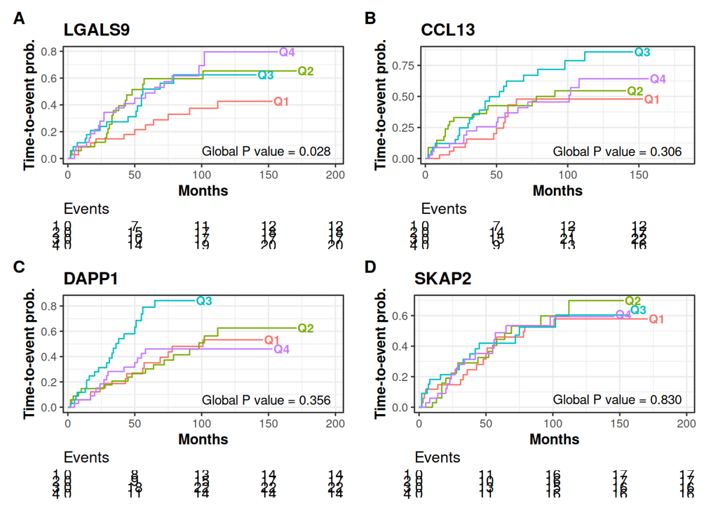

```r
# svg("../results/fig5_KM_main.svg", width = 8, height = 8)
fig5
```

```r
# dev.off()
```

### Outcome-specific comparisons (Figs. S7-S9)

```r
fits_nadm  <- purrr::map(marker_data, ~ survfit2(Surv(time, as.factor(nadm)) ~ quantile, data = .x))

figS7 <- build_4panel_km(
    plot_cuminc_pub(fits_nadm$LGALS9, "LGALS9", p_text = p_text_for("LGALS9", "nadm")),
    plot_cuminc_pub(fits_nadm$CCL13,  "CCL13",  p_text = p_text_for("CCL13", "nadm")),
    plot_cuminc_pub(fits_nadm$DAPP1,  "DAPP1",  p_text = p_text_for("DAPP1", "nadm")),
    plot_cuminc_pub(fits_nadm$SKAP2,  "SKAP2",  p_text = p_text_for("SKAP2", "nadm"))
)
```

```
Plotting outcome "1".
Plotting outcome "1".
Plotting outcome "1".
Plotting outcome "1".
```

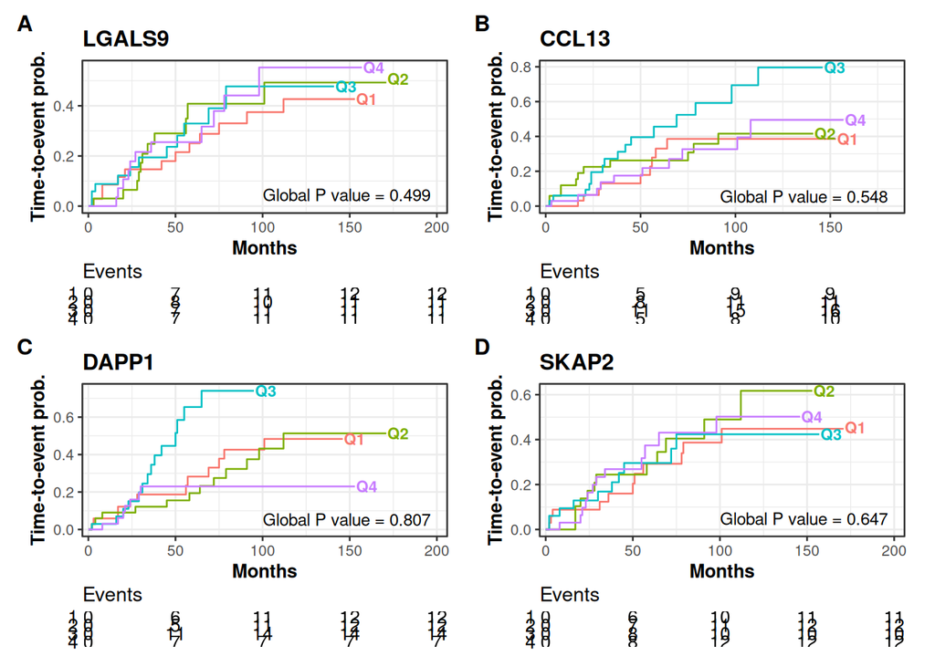

```r
# svg("../results/figS7_KM_nadm.svg", width = 8, height = 8)
figS7
```

```r
# dev.off()
```

```r
fits_mace  <- purrr::map(marker_data, ~ survfit2(Surv(time, as.factor(mace)) ~ quantile, data = .x))

figS8 <- build_4panel_km(
    plot_cuminc_pub(fits_mace$LGALS9, "LGALS9", p_text = p_text_for("LGALS9", "mace")),
    plot_cuminc_pub(fits_mace$CCL13,  "CCL13",  p_text = p_text_for("CCL13", "mace")),
    plot_cuminc_pub(fits_mace$DAPP1,  "DAPP1",  p_text = p_text_for("DAPP1", "mace")),
    plot_cuminc_pub(fits_mace$SKAP2,  "SKAP2",  p_text = p_text_for("SKAP2", "mace"))
)
```

```
Plotting outcome "1".
Plotting outcome "1".
Plotting outcome "1".
Plotting outcome "1".
```

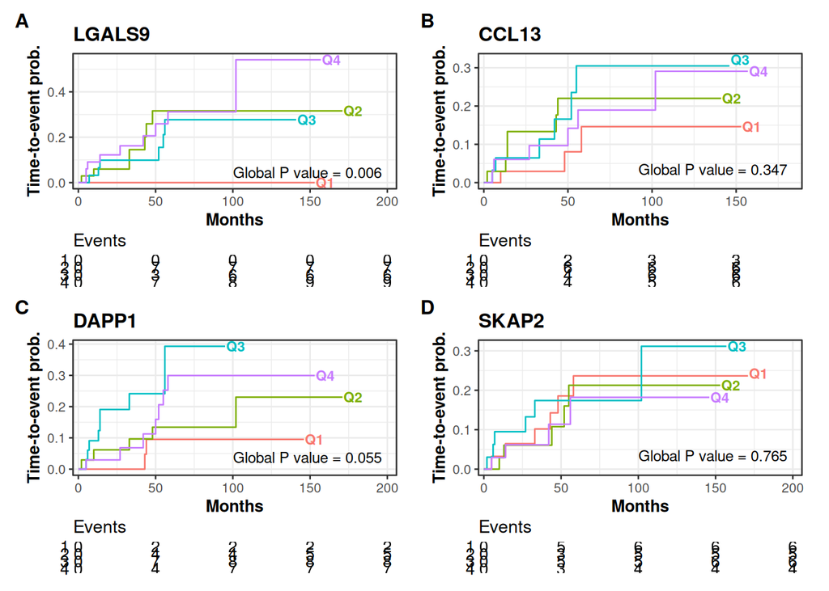

```r
# svg("../results/figS8_KM_mace.svg", width = 8, height = 8)
figS8
```

```r
# dev.off()
```

```r
fits_death <- purrr::map(marker_data, ~ survfit2(Surv(time, as.factor(death_all)) ~ quantile, data = .x))

figS9 <- build_4panel_km(
    plot_cuminc_pub(fits_death$LGALS9, "LGALS9", p_text = p_text_for("LGALS9", "death_all")),
    plot_cuminc_pub(fits_death$CCL13,  "CCL13",  p_text = p_text_for("CCL13", "death_all")),
    plot_cuminc_pub(fits_death$DAPP1,  "DAPP1",  p_text = p_text_for("DAPP1", "death_all")),
    plot_cuminc_pub(fits_death$SKAP2,  "SKAP2",  p_text = p_text_for("SKAP2", "death_all"))
)
```

```
Plotting outcome "1".
Plotting outcome "1".
Plotting outcome "1".
Plotting outcome "1".
```

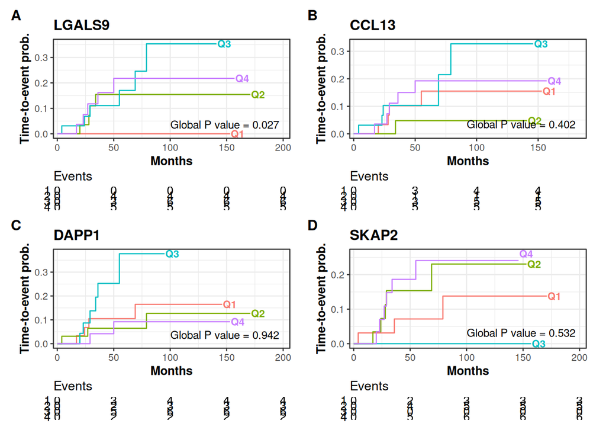

```r
# svg("../results/figS9_KM_death.svg", width = 8, height = 8)
figS9
```

```r
# dev.off()
```

## Non-linearity: penalized spline models (Fig. S6)

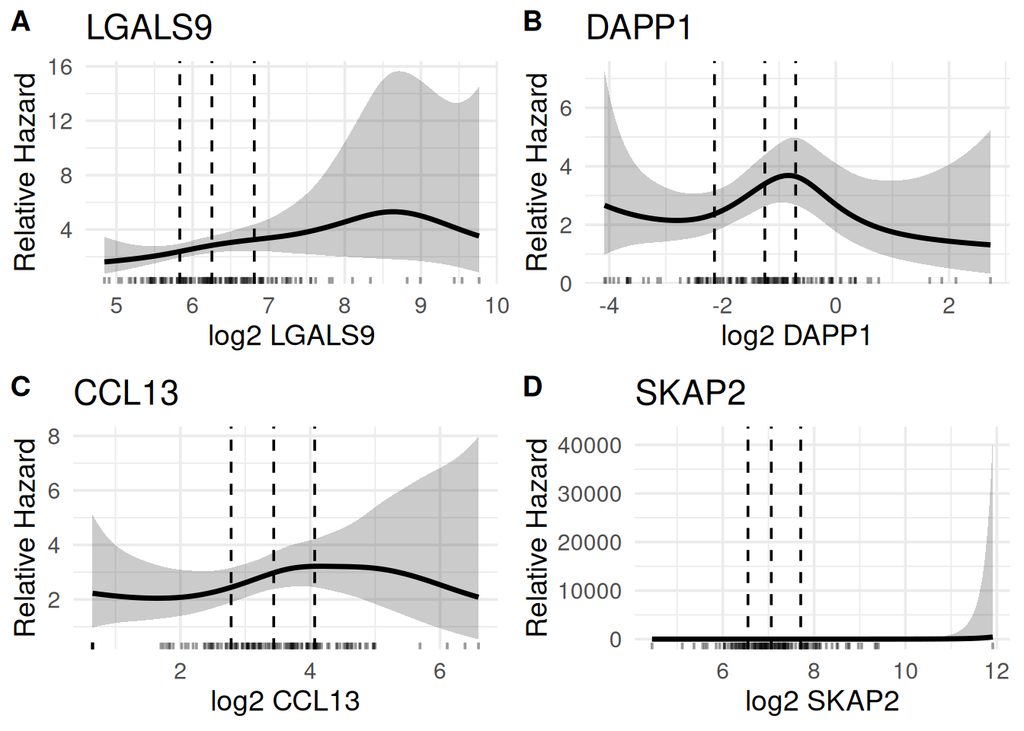

```r
fit_spline_plot <- function(data, marker) {
    data <- data |>
        mutate(log2_conc = log2(mean_conc)) |>
        filter(!is.na(log2_conc), !is.na(time), !is.na(group))

    cox_pspline <- coxph(Surv(time, as.numeric(group)) ~ pspline(log2_conc, df = 3), data = data)

    newdat <- data.frame(log2_conc = seq(min(data$log2_conc), max(data$log2_conc), length = 200))
    pred <- predict(cox_pspline, newdata = newdat, type = "risk", se.fit = TRUE)

    plotdat <- newdat |>
        mutate(HR = exp(pred$fit), HR_low = exp(pred$fit - 1.96 * pred$se.fit),
               HR_high = exp(pred$fit + 1.96 * pred$se.fit))
    q_vals <- quantile(data$log2_conc, probs = c(0.25, 0.50, 0.75), na.rm = TRUE)

    ggplot(plotdat, aes(x = log2_conc, y = HR)) +
        geom_ribbon(aes(ymin = HR_low, ymax = HR_high), alpha = 0.25) +
        geom_line(linewidth = 1.2) +
        geom_vline(xintercept = q_vals, linetype = "dashed", color = "black") +
        geom_rug(data = data, aes(x = log2_conc), sides = "b", alpha = 0.4, inherit.aes = FALSE) +
        scale_x_continuous(paste0("log2 ", marker)) +
        scale_y_continuous("Relative Hazard") +
        theme_minimal(base_size = 14) +
        ggtitle(marker)
}

spline_plots <- purrr::imap(marker_data, fit_spline_plot)
figS6 <- ggarrange(plotlist = spline_plots[c("LGALS9", "DAPP1", "CCL13", "SKAP2")], labels = "AUTO")

# svg("../results/figS6_non_linearity.svg", width = 7, height = 7)
figS6
```

```r
# dev.off()
```

## Assessment of proportional hazards assumption (Fig. S11)

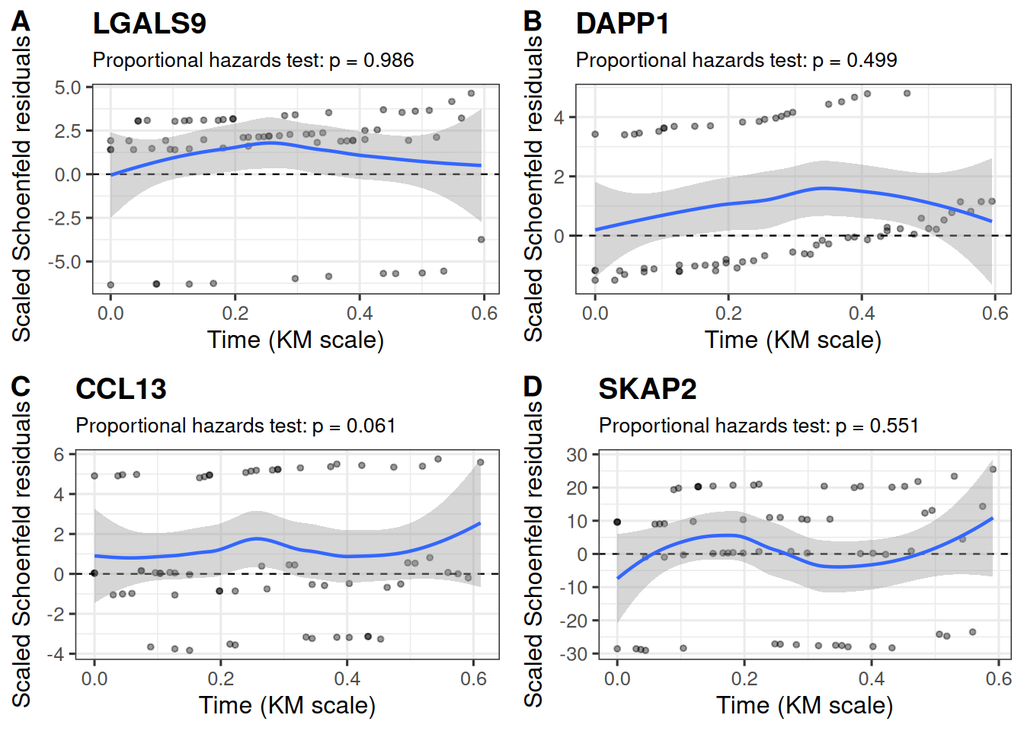

```r
plot_schoenfeld_gg <- function(model, xlab = "Time (KM scale)",
                               ylab = "Scaled Schoenfeld residuals", title = NULL) {
    pval <- model$ph$table[1, "p"]

    ggplot(model$df, aes(time, resid)) +
        geom_hline(yintercept = 0, linetype = 2, linewidth = 0.4) +
        geom_point(alpha = 0.4, size = 1) +
        geom_smooth(method = "loess", se = TRUE, span = 0.9, linewidth = 0.8) +
        labs(x = xlab, y = ylab, title = title,
             subtitle = paste0("Proportional hazards test: p = ", formatC(pval, digits = 3, format = "f"))) +
        theme_bw(base_size = 12) +
        theme(plot.title = element_text(face = "bold"), plot.subtitle = element_text(size = 10))
}

schoenfeld_plots <- purrr::imap(schoenfeld_models, ~ plot_schoenfeld_gg(.x, title = .y))

figS11 <- ggarrange(plotlist = schoenfeld_plots[c("LGALS9", "DAPP1", "CCL13", "SKAP2")], labels = "AUTO")
# svg("../results/figS11_schoenfeld.svg", width = 7, height = 7)
figS11
```

```r
# dev.off()
```

## Forest plot: hazard ratios by quartile across outcomes (Fig. S5)

```r
forest_data <- purrr::imap_dfr(categorical_models, function(models_by_outcome, marker) {
    purrr::imap_dfr(
        list(
            "Any SNAE" = models_by_outcome$group$crude,
            "Non-AIDS-defining malignancy" = models_by_outcome$nadm$crude,
            "Major cardiovascular event" = models_by_outcome$mace$crude,
            "Mortality" = models_by_outcome$death_all$crude
        ),
        function(model, outcome) {
            tibble(
                biomarker = marker, outcome = outcome,
                n = model$n, events = model$nevent,
                broom::tidy(model, conf.int = TRUE, exponentiate = TRUE)
            )
        }
    )
}) |>
    filter(str_detect(term, "^quantile")) |>
    mutate(
        quartile = recode(term, "quantile2" = "Q2 vs Q1", "quantile3" = "Q3 vs Q1", "quantile4" = "Q4 vs Q1"),
        quartile = factor(quartile, levels = c("Q4 vs Q1", "Q3 vs Q1", "Q2 vs Q1")),
        outcome = factor(outcome, levels = c("Any SNAE", "Non-AIDS-defining malignancy",
                                             "Major cardiovascular event", "Mortality")),
        biomarker = factor(biomarker, levels = markers),
        estimable = is.finite(estimate) & is.finite(conf.low) & is.finite(conf.high) & conf.low > 0
    )

forest_data |> arrange(biomarker, outcome, quartile)
```

| biomarker | outcome | n | events | term | estimate | std.error | statistic | p.value | conf.low | conf.high | quartile | estimable |
| --- | --- | --- | --- | --- | --- | --- | --- | --- | --- | --- | --- | --- |
| LGALS9 | Any SNAE | 136 | 67 | quantile4 | 2.371884e+00 | 0.3676642 | 2.349112851 | 0.018818202 | 1.15381762 | 4.875845 | Q4 vs Q1 | TRUE |
| LGALS9 | Any SNAE | 136 | 67 | quantile3 | 2.041199e+00 | 0.3799400 | 1.878026575 | 0.060377530 | 0.96934829 | 4.298243 | Q3 vs Q1 | TRUE |
| LGALS9 | Any SNAE | 136 | 67 | quantile2 | 2.139915e+00 | 0.3750787 | 2.028283598 | 0.042531312 | 1.02595638 | 4.463381 | Q2 vs Q1 | TRUE |
| LGALS9 | Non-AIDS-defining malignancy | 136 | 45 | quantile4 | 1.315185e+00 | 0.4204360 | 0.651650165 | 0.514626878 | 0.57691394 | 2.998213 | Q4 vs Q1 | TRUE |
| LGALS9 | Non-AIDS-defining malignancy | 136 | 45 | quantile3 | 1.351863e+00 | 0.4215025 | 0.715259677 | 0.474448600 | 0.59176485 | 3.088277 | Q3 vs Q1 | TRUE |
| LGALS9 | Non-AIDS-defining malignancy | 136 | 45 | quantile2 | 1.306692e+00 | 0.4206660 | 0.635893485 | 0.524845850 | 0.57293019 | 2.980195 | Q2 vs Q1 | TRUE |
| LGALS9 | Major cardiovascular event | 136 | 22 | quantile4 | 4.318096e+08 | 5873.9895930 | 0.003385007 | 0.997299160 | 0.00000000 | Inf | Q4 vs Q1 | FALSE |
| LGALS9 | Major cardiovascular event | 136 | 22 | quantile3 | 2.815473e+08 | 5873.9895976 | 0.003312197 | 0.997357254 | 0.00000000 | Inf | Q3 vs Q1 | FALSE |
| LGALS9 | Major cardiovascular event | 136 | 22 | quantile2 | 3.428347e+08 | 5873.9895955 | 0.003345726 | 0.997330502 | 0.00000000 | Inf | Q2 vs Q1 | FALSE |
| LGALS9 | Mortality | 136 | 15 | quantile4 | 3.415635e+08 | 7153.1894077 | 0.002746893 | 0.997808299 | 0.00000000 | Inf | Q4 vs Q1 | FALSE |

[output cut: 38 more lines]

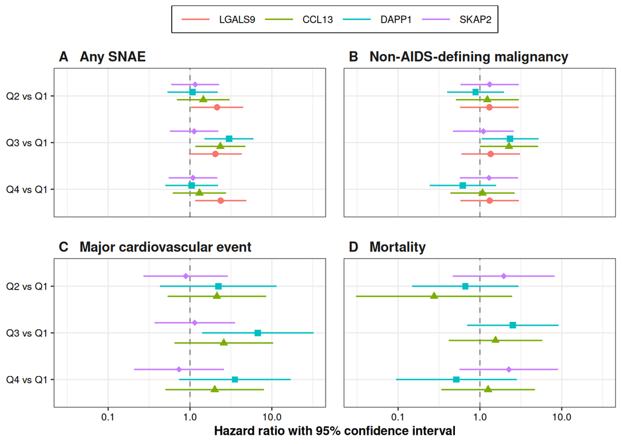

```r
forest_plot_data <- forest_data |>
    filter(estimable)

panel_labels <- c(
    "Any SNAE" = "A   Any SNAE",
    "Non-AIDS-defining malignancy" = "B   Non-AIDS-defining malignancy",
    "Major cardiovascular event" = "C   Major cardiovascular event",
    "Mortality" = "D   Mortality"
)

forest_plot <- ggplot(
    forest_plot_data,
    aes(x = quartile, y = estimate, ymin = conf.low, ymax = conf.high,
        colour = biomarker, shape = biomarker, group = biomarker)
) +
    geom_hline(yintercept = 1, linetype = "dashed", colour = "grey55", linewidth = 0.5) +
    geom_pointrange(position = position_dodge(width = 0.65), linewidth = 0.55,
                    key_glyph = ggplot2::draw_key_path) +
    scale_y_log10() +
    scale_colour_manual(
        values = c("LGALS9" = "#F8766D", "CCL13" = "#7CAE00", "DAPP1" = "#00BFC4", "SKAP2" = "#C77CFF"),
        drop = FALSE
    ) +
    scale_shape_manual(
        values = c("LGALS9" = 16, "CCL13" = 17, "DAPP1" = 15, "SKAP2" = 18),
        drop = FALSE
    ) +
    guides(colour = guide_legend(nrow = 1, byrow = TRUE), shape = "none") +
    facet_wrap(~ outcome, ncol = 2, labeller = as_labeller(panel_labels)) +
    coord_flip() +
    labs(x = NULL, y = "Hazard ratio with 95% confidence interval", colour = NULL, shape = NULL) +
    theme_bw(base_size = 10) +
    theme(
        axis.title = element_text(face = "bold"),
        axis.text = element_text(colour = "black"),
        legend.position = "top",
        legend.justification = "center",
        legend.direction = "horizontal",
        legend.box.just = "center",
        legend.box.background = element_rect(colour = "black", fill = "white", linewidth = 0.5),
        legend.key.width = grid::unit(1, "cm"),
        legend.key.height = grid::unit(0.4, "cm"),
        strip.background = element_blank(),
        strip.text = element_text(face = "bold", hjust = 0, size = 11),
        panel.spacing = grid::unit(1, "lines")
    )

# svg("../results/figS5_forest_plot.svg", width = 7, height = 7)
forest_plot
```

```r
# dev.off()
```